```python
import sys
import os

import numpy as np
import pandas as pd
import seaborn as sns
from sklearn import preprocessing
import matplotlib.pyplot as plt

import mltoolbox
from mltoolbox.exploration import FacetsExploration
from mltoolbox.forecasts import ForecastProphet
from mltoolbox.classifiers import Ptsne, Hyperoptimizer, candidates, TsneClassifier
from mltoolbox.datasets import dset

seed = 1 # fixed for reproducibility


# 1. Set `PYTHONHASHSEED` environment variable at a fixed value
os.environ['PYTHONHASHSEED']=str(seed)

# 2. Set `python` built-in pseudo-random generator at a fixed value
import random
random.seed(seed)

# 3. Set `numpy` pseudo-random generator at a fixed value
np.random.seed(seed)

# 4. Set `tensorflow` pseudo-random generator at a fixed value
import tensorflow as tf
tf.set_random_seed(seed)

# 5. Configure a new global `tensorflow` session
from keras import backend as K
session_conf = tf.ConfigProto(intra_op_parallelism_threads=1, inter_op_parallelism_threads=1)
sess = tf.Session(graph=tf.get_default_graph(), config=session_conf)
K.set_session(sess)
```

```
ERROR:fbprophet:Importing plotly failed. Interactive plots will not work.
```

# **Forecasting with Fb Prophet**

We use footfal data from the streets of York (open-source dataset from https://data.yorkopendata.org/dataset/footfall) to test the ForecastProphet class. For test purpose, only a subset of the dataset is used (Coney Street, last 120 days). Data split in training / test sets, z-scored, and UK holidays are added before fitting the model. Footfall forecast is plotted along with goodness of fit and residual plots.

```
C:\Users\Cristi\Anaconda3\envs\handyman\Lib\site-packages\mltoolbox\datasets\footfallhourly.csv

Applying normalization fitting a scaler to the training dataset and using the same transformation on the test set.
```

```
INFO:fbprophet:Disabling yearly seasonality. Run prophet with yearly_seasonality=True to override this.
```

```
Dataset with 1 columns.
  - Target column(s): TotalCount.
Function "ForecastProphet.fit" - Elapsed time: 1.72 seconds.
Function "ForecastProphet.predict" - Elapsed time: 10.02 seconds.
```

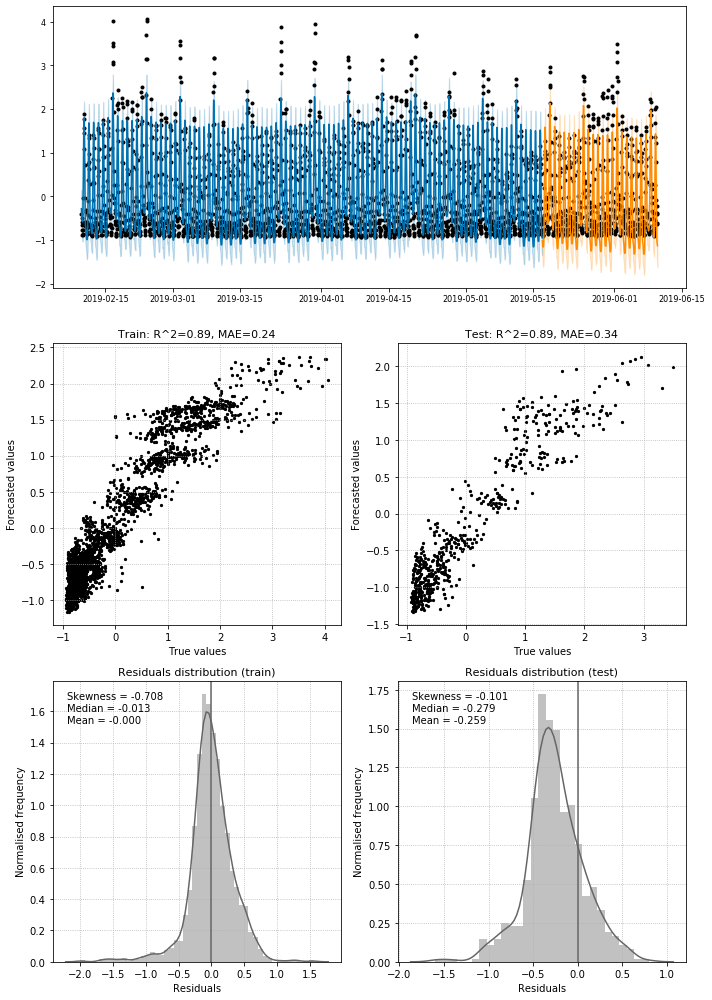

```python
            package_path = os.path.dirname(mltoolbox.__file__).replace(os.path.sep + 'lib' + os.path.sep,
                                                                       os.path.sep + 'Lib' + os.path.sep)

            # data = pd.read_csv(r'./datasets/footfallhourly.csv')
            filepath = package_path + os.path.join(os.sep, 'datasets', 'footfallhourly.csv')
            print(filepath)
            data = pd.read_csv(filepath)
            data = data[data['LocationName'] == 'Coney Street'][
                ['Date', 'TotalCount']
            ].copy()

            data = data.tail(24 * 120)  # keep 120 days
            data.Date = pd.to_datetime(data.Date, format='%d/%m/%Y %H:%M:%S').dt.strftime(
                '%Y-%m-%d %H:%M:%S'
            )
            data.index = data.Date
            data = data.drop(columns=['Date'])

            # convert to dset
            ds = dset(data=data, target=['TotalCount'])

            (ds
             .remove_nan_rows(any_nan=True)
             .split_train_test_sets(train_test_split=0.2, shuffle_split=False, seed=0)
             .normalize(columns=[ds.target], type='zscore')
             .summary()
             )


            ff = ForecastProphet(
                input_dset=ds, input_y_column='TotalCount',input_ds_column='index'
            )

            ff.add_country_holidays(country_name='UK')

            ff.evaluate_train_test()
```

# **Data exploration with Facets**

Dataset: Diamonds dataset from seaborn. Data split 40%-60% to showcase comparison of two datasets.

Facets open as two separate browser tabs.

```python
        data = sns.load_dataset('diamonds')
        fo = FacetsExploration(
            input_data={
                'dataset1': data.sample(n=6000,random_state=0),
                'dataset2': data.sample(n=9000,random_state=0),
            }
        )
        fo.generate_overview_html_string()
        fo.generate_dive_html_string(data=fo.data['dataset2'])

        fo.show(type='overview')
        fo.show(type='dive')
```

```
Function "FacetsExploration.prepare_data" - Elapsed time: 0.38 seconds.
```

# **Classifiers**

This section demos:

- Dset - a "dataset" class that incorporates methods for data cleaning and normalization, train/test spleating, PCA, and more.
- Hyperoptimizer - which takes multiple sklearn-like classifiers and a list of parameter ranges and finds the best combination to maximize accuracy.
- Tsne - a class that first fits t-Distributed Stochastic Neighbor Embedding (t-SNE) to the training data, then uses Keras to learn the embedding and apply it to new (test) data.

## Classification dataset

Generated using sklearn's make_classification: 1000 samples, 4 classes, 10 features (6 information features, 4 redundant features).

```python
#         data = sns.load_dataset('iris')

        from sklearn.datasets import make_classification
        X1, Y1 = make_classification(n_samples=1000, n_features=10, n_redundant=4, n_informative=6,
                                     n_clusters_per_class=1, n_classes=4)
        data = pd.DataFrame(X1, columns=['feat' + str(i) for i in range(X1.shape[1])])
        data_labels = pd.DataFrame(Y1, columns=['target'])
        data = data.join(data_labels)
        ds = dset(data, target=["target"], header=0, target_type='')
```

## Dset class

Put the data in the "dset" class, split it in 50-50% train and test sets, and normalize it.

```python
        ds = dset(data, target=["target"], header=0, target_type='')

        (ds
         .remove_nan_rows(columns=[ds.target], any_nan=True)
         .remove_nan_columns(any_nan=True)
         .categorical2numeric(exclude_target_column=False)
         .split_train_test_sets(train_test_split=0.5, shuffle_split=True, seed=0)
         .normalize(type='robust')
         .summary()
         )
```

```
Columns for normalization not explicitely specified. Will use all columns defined as variables.

Applying normalization fitting a scaler to the training dataset and using the same transformation on the test set.

Dataset with 11 columns.
  - Target column(s): ['target'].
```

# Hyperoptimizer

First we attempt the classification on the high-dimensional data set. The hyperoptimizer is tested on 5 classifiers: Random Forest (rf), Multi-layer peceptron (MLP), XGboost (xgb) and Gaussian Process Classifier (gpc), k-nearest neighbours (knn).

```python
        for c in candidates.keys():
            print('\n')
            for k in candidates[c].keys():
                print(candidates[c][k])
        print('\n')

        variables = [c for c in ds.variables if c not in ds.target]
        hopt_regular = (Hyperoptimizer(candidates=candidates, type='classification',
                               x_train=ds.train_set[variables],
                               y_train=ds.labels_train,
                               x_test=ds.test_set[variables],
                               y_test=ds.labels_test,
                               n_iter=20)
                .run()
                )
```

```
GaussianProcessClassifier(copy_X_train=True, kernel=None,
             max_iter_predict=100, multi_class='one_vs_rest', n_jobs=None,
             n_restarts_optimizer=0, optimizer='fmin_l_bfgs_b',
             random_state=None, warm_start=False)
{'random_state': (0,), 'max_iter_predict': (50, 1000), 'multi_class': ['one_vs_rest', 'one_vs_one']}


KNeighborsClassifier(algorithm='auto', leaf_size=30, metric='minkowski',
           metric_params=None, n_jobs=None, n_neighbors=5, p=2,
           weights='uniform')
{'n_neighbors': (3, 25)}


RandomForestClassifier(bootstrap=True, class_weight=None, criterion='gini',
            max_depth=None, max_features='auto', max_leaf_nodes=None,
            min_impurity_decrease=0.0, min_impurity_split=None,
            min_samples_leaf=1, min_samples_split=2,
            min_weight_fraction_leaf=0.0, n_estimators='warn', n_jobs=None,
            oob_score=False, random_state=None, verbose=0,
            warm_start=False)
{'random_state': (0,), 'n_estimators': (10, 2000), 'max_depth': (2, 6), 'min_samples_leaf': (1, 10)}


XGBClassifier(base_score=0.5, booster='gbtree', colsample_bylevel=1,
       colsample_bynode=1, colsample_bytree=1, gamma=0, learning_rate=0.1,
       max_delta_step=0, max_depth=3, min_child_weight=1, missing=None,
       n_estimators=100, n_jobs=1, nthread=None,
       objective='binary:logistic', random_state=0, reg_alpha=0,
       reg_lambda=1, scale_pos_weight=1, seed=None, silent=None,
       subsample=1, verbosity=1)
{'random_state': (0,), 'learning_rate': (0.0001, 1, 'log-uniform'), 'n_estimators': (50, 7000), 'max_depth': (2, 6), 'reg_alpha': (0.0001, 0.5, 'log-uniform'), 'reg_lambda': (0.0001, 0.5, 'log-uniform'), 'booster': ['gbtree', 'gblinear']}


MLPClassifier(activation='relu', alpha=0.0001, batch_size='auto', beta_1=0.9,
       beta_2=0.999, early_stopping=False, epsilon=1e-08,
       hidden_layer_sizes=(100,), learning_rate='constant',
       learning_rate_init=0.001, max_iter=200, momentum=0.9,
       n_iter_no_change=10, nesterovs_momentum=True, power_t=0.5,
       random_state=None, shuffle=True, solver='adam', tol=0.0001,
       validation_fraction=0.1, verbose=False, warm_start=False)
{'random_state': (0,), 'learning_rate_init': (0.0001, 1, 'log-uniform'), 'alpha': (0.0001, 0.5, 'log-uniform'), 'max_iter': (200, 10000)}


Starting hyperoptimization of 5 algorithms.
Model: Training gpc...Function "Hyperoptimizer.optimize" - Elapsed time: 171.42 seconds.
 took 171.519 seconds.
  * Test score: [0.8940]
Model: Training knn...Function "Hyperoptimizer.optimize" - Elapsed time: 5.86 seconds.
 took 5.959 seconds.
  * Test score: [0.8580]
Model: Training rf...Function "Hyperoptimizer.optimize" - Elapsed time: 28.25 seconds.
 took 28.349 seconds.
  * Test score: [0.8600]
Model: Training xgb...Function "Hyperoptimizer.optimize" - Elapsed time: 73.71 seconds.
 took 73.816 seconds.
  * Test score: [0.8840]
Model: Training mlp...Function "Hyperoptimizer.optimize" - Elapsed time: 29.02 seconds.
 took 29.117 seconds.
  * Test score: [0.9020]
Function "Hyperoptimizer.run" - Elapsed time: 309.27 seconds.
```

# t-SNE

First we need to make sure t-SNE provides a good separation of classes in the low dimensional spaces. This is done by tuning t-SNE parameters and re-fitting.

```python
        t = TsneClassifier(input_dset=ds,  n_components=2, perplexity=12, early_exaggeration=12, n_iter=1000, random_state=0)
        t.tsne_fit( )
```

```
TsneClassifier(early_exaggeration=12, input_dset=None, learning_rate=200.0,
        n_components=2, n_iter=1000, perplexity=12, random_state=0)
```

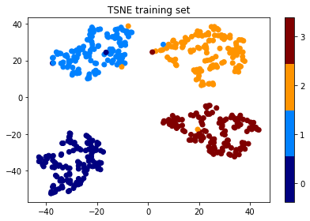

```python
        t.plot_tsne_fit()
```

Now we use Keras to learn the mapping from high to low dimensional space.

```python
        t.fit(epochs=1500, hidden_neurons=[200, 200, 200], activation='tanh',  dropout=0.25, validation_split=0.2, verbose=0, loss=t.euclidean_distance_loss, metrics=[t.euclidean_distance_loss])
        t.transform2tsne()
```

[output not shown]

```
Function "TsneClassifier.fit" - Elapsed time: 59.55 seconds.
```

Plot training and validation loss. The model is trained with early stopping and save model checkpoint callbacks.

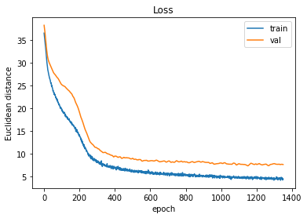

```python
        plt.plot(t.keras_model_history.history['loss'],)
        plt.plot(t.keras_model_history.history['val_loss'])
        plt.title('Loss')
        plt.ylabel('Euclidean distance')
        plt.xlabel('epoch')
        plt.legend(['train', 'val'], loc='upper right')
```

t-SNE mapping is plotted on top on the initial data points, to visually evaluate the mapping.

[figure not shown]

```python
        le= preprocessing.LabelEncoder()
        train_labels = le.fit_transform(t.labels_train.values)
        test_labels = le.fit_transform(t.labels_test.values)

        plt.figure()
        plt.scatter(t.tsne['train_set'][:, 0], t.tsne['train_set'][:, 1],  c=train_labels)
        plt.scatter(t.fitted_train[:, 0], t.fitted_train[:, 1], marker='s', c=train_labels, edgecolors='r')
        plt.scatter(t.fitted_test[:, 0], t.fitted_test[:, 1], marker='d', c=test_labels, edgecolors='k')
        plt.title('t-SNE parametrization (circle - tSNE, square - Keras mapping (train), diamond - Keras mapping (test) )')
```

```
Starting hyperoptimization of 5 algorithms.
Model: Training gpc...Function "Hyperoptimizer.optimize" - Elapsed time: 128.72 seconds.
 took 128.818 seconds.
  * Test score: [0.9160]
Model: Training knn...Function "Hyperoptimizer.optimize" - Elapsed time: 3.64 seconds.
 took 3.744 seconds.
  * Test score: [0.9200]
Model: Training rf...Function "Hyperoptimizer.optimize" - Elapsed time: 16.37 seconds.
 took 16.473 seconds.
  * Test score: [0.9320]
Model: Training xgb...Function "Hyperoptimizer.optimize" - Elapsed time: 68.18 seconds.
 took 68.280 seconds.
  * Test score: [0.9260]
Model: Training mlp...Function "Hyperoptimizer.optimize" - Elapsed time: 13.88 seconds.
 took 13.986 seconds.
  * Test score: [0.9280]
Function "Hyperoptimizer.run" - Elapsed time: 231.81 seconds.
one_vs_one multi-class mode does not support predicting probability estimates. Use one_vs_rest mode instead.
```

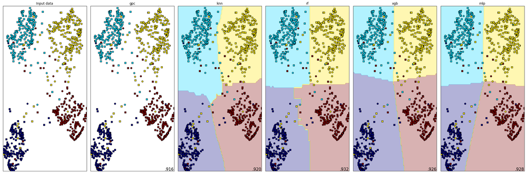

```
Function "Hyperoptimizer.plot_comparison" - Elapsed time: 2.97 seconds.
```

```python
        hopt_tsne = (Hyperoptimizer(candidates=candidates, type='classification',
                               x_train=t.fitted_train,
                               y_train=t.labels_train,
                               x_test=t.fitted_test,
                               y_test=t.labels_test,
                               n_iter=20, seed=0)
                .run()
                .plot_comparison(mesh_resolution=None)
                )
```

## Comparison of classification results

```python
    print('\n Classification results on high-dimensional dataset  (with hyperoptimization)')
    hopt_regular.summary()

    print('\n Classification results on low-dimensional dataset (with hyperoptimization)')
    hopt_tsne.summary()
```

```
 Classification results on high-dimensional dataset  (with hyperoptimization)
     score runtime_seconds
mlp  0.902          29.117
gpc  0.894         171.519
xgb  0.884          73.816
rf    0.86          28.349
knn  0.858         5.95938

 Classification results on low-dimensional dataset (with hyperoptimization)
     score runtime_seconds
rf   0.932          16.473
mlp  0.928          13.986
xgb  0.926           68.28
knn   0.92         3.74422
gpc  0.916         128.818
```

```
<mltoolbox.classifiers.Hyperoptimizer at 0x2d586904278>
```